# 2020 Q

## Final Q for FRCH PT1

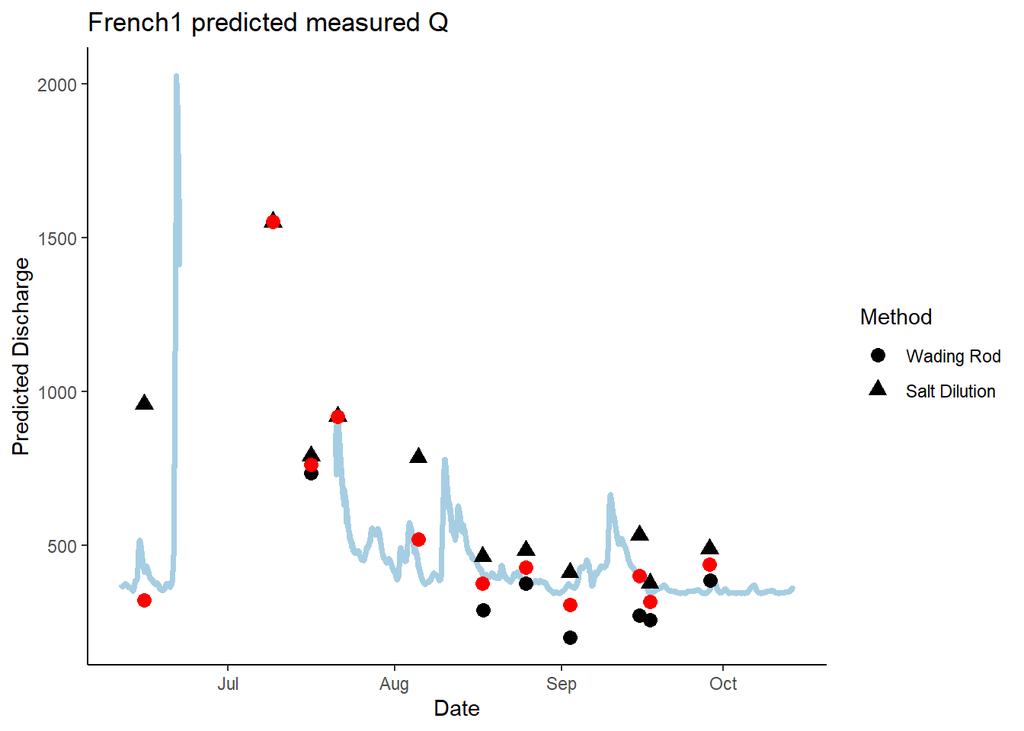

Red are the points used in the rating curve (if they had pressure data).

## Raw Rating curve FRCH PT2

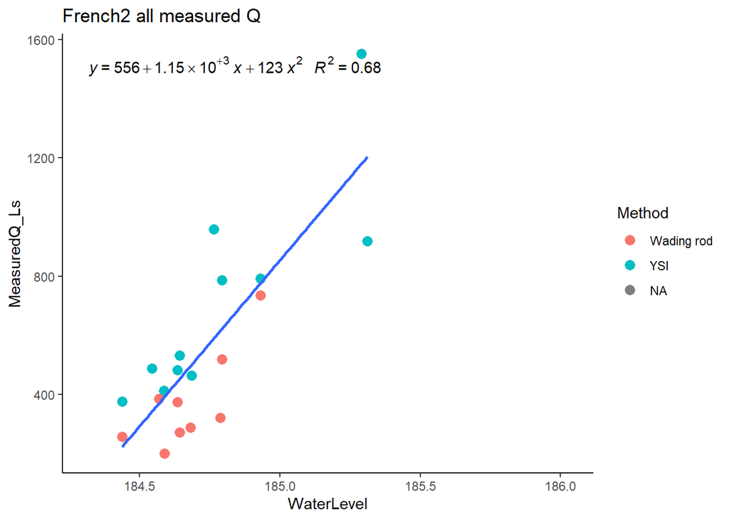

Lets remove the highest YSI points, then only use the wading rod and next highest YSI point.

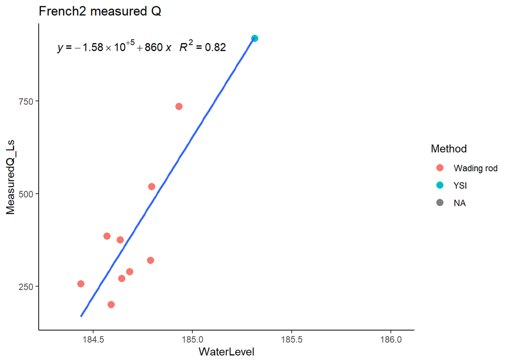

Lets try the same averaging proccess as before.

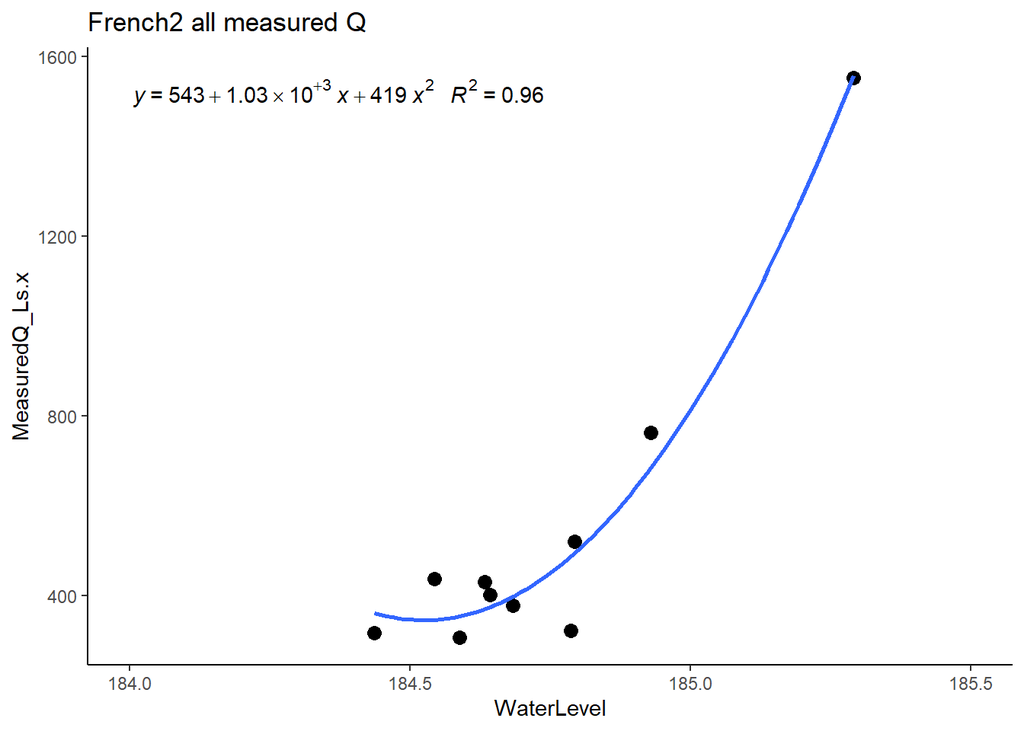

## Final Q for FRCH PT2

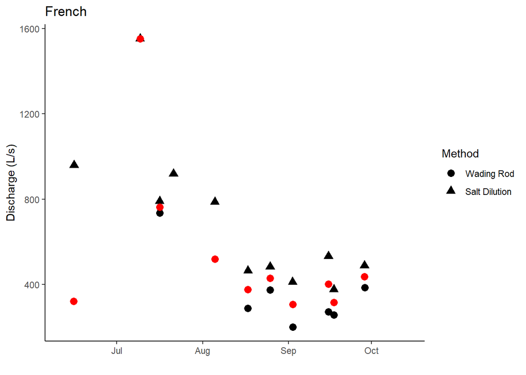

Looks pretty good

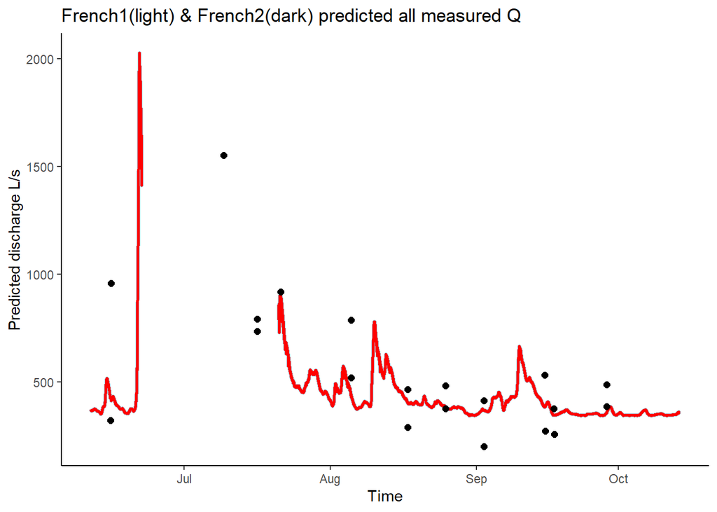

Red is the average and should be exported to a csv.

## Export PT data to csv in DoD_Discharge->Predicted_Discharge->2020

# Poker

## Raw Poker PT1

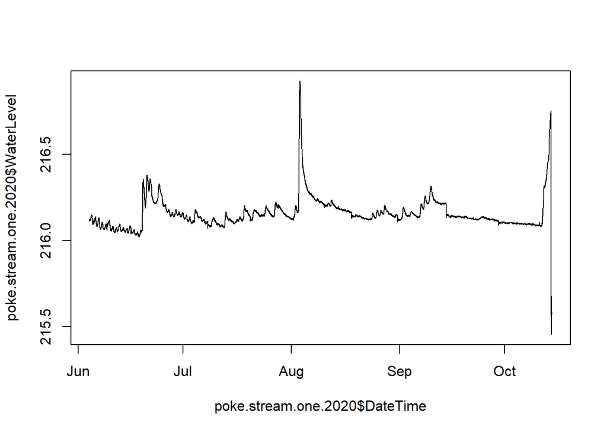

It looks like I need to remove out of water points at the end of the year and potentially shift middle of september-on up….let the cleaning commence!

Poker PT1 2.0

```
## [1] 0.068
```

[output not shown]

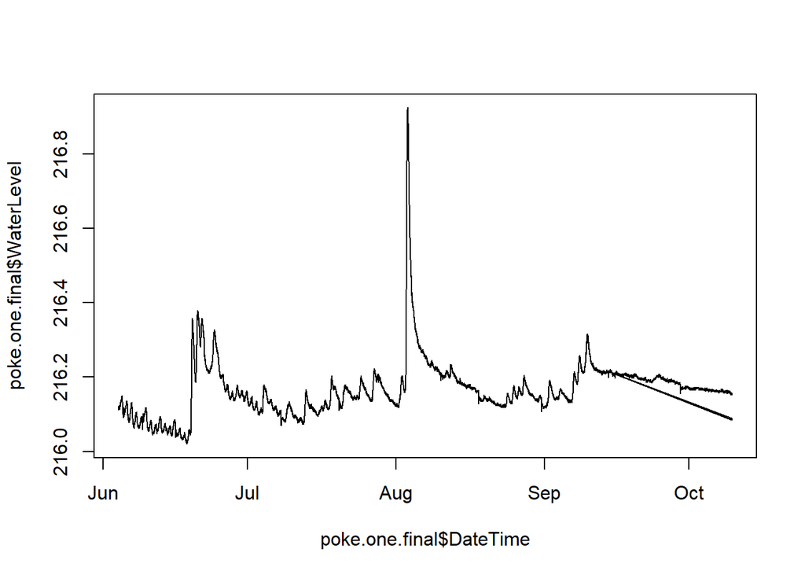

1. removed data after 10/10/20 due to decommission
2. shifted mid september-on up due to dip

## Raw Poker PT2

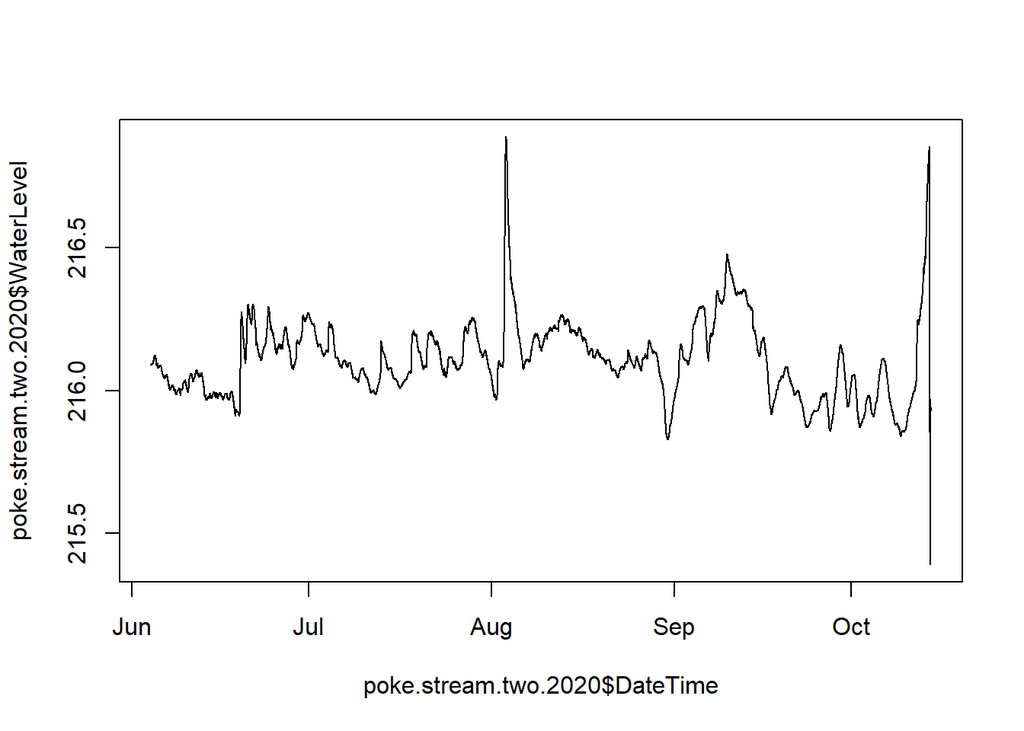

PT2 seems a lot “noisier”….this is the PT that is located on the wetttetd edge left side tucked by the meander so it is more susecptible to shaking….It also needs to be filtered out at the end of the season due to out of water points….let the cleaning commence!

Poker PT2 2.0

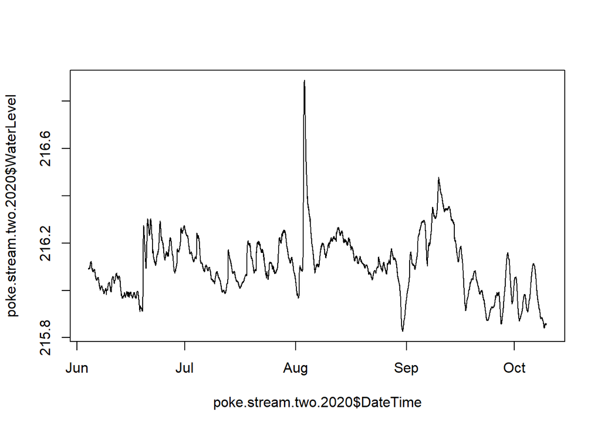

## Export PT data to csv in DoD_Discharge->PT_data->2020

## Raw Rating curve POKE PT1

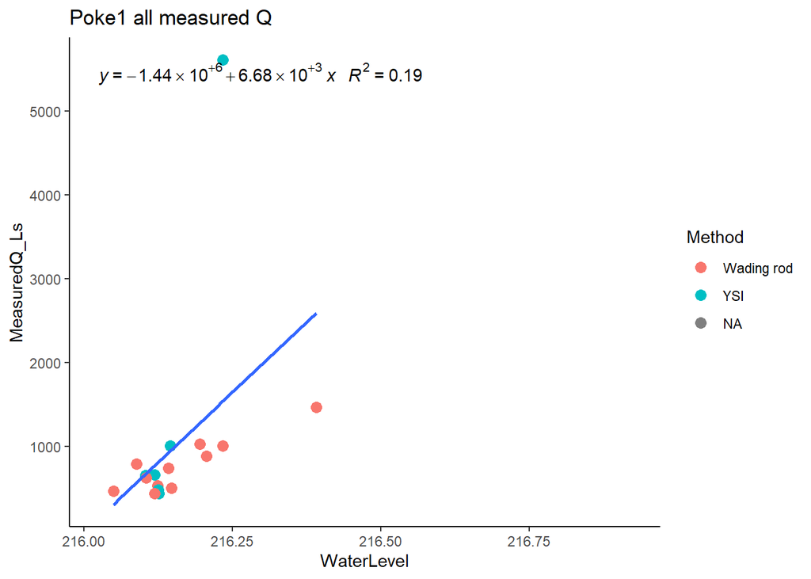

top YSI point has got to go

Rating curve POKE PT1 2.0

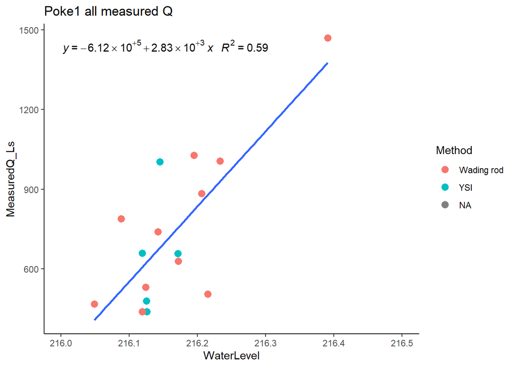

1. removed the top YSI point

## Raw Rating curve POKE PT2

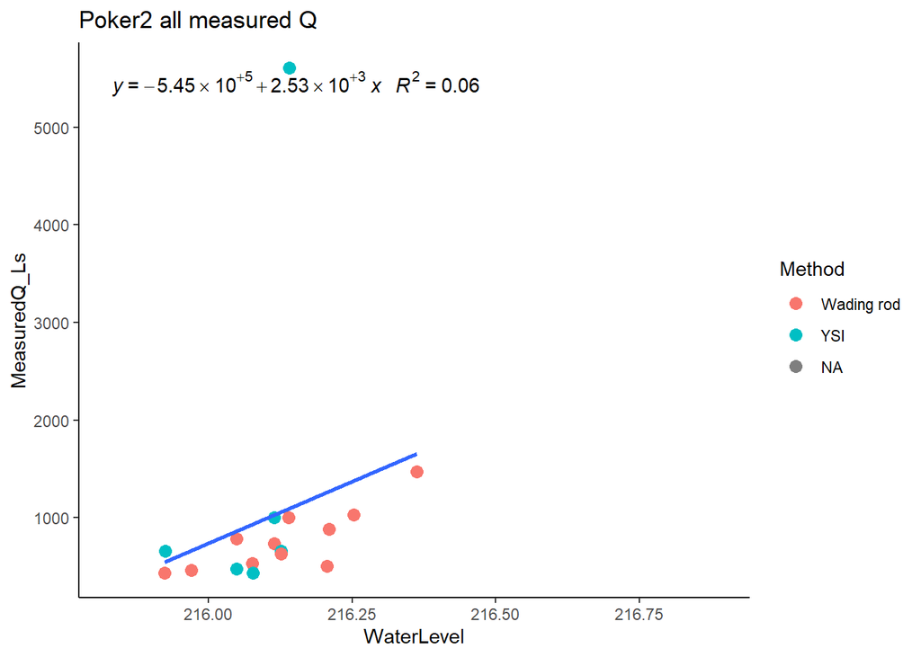

Need to remove the top YSI point

## Raw Rating curve POKE PT2

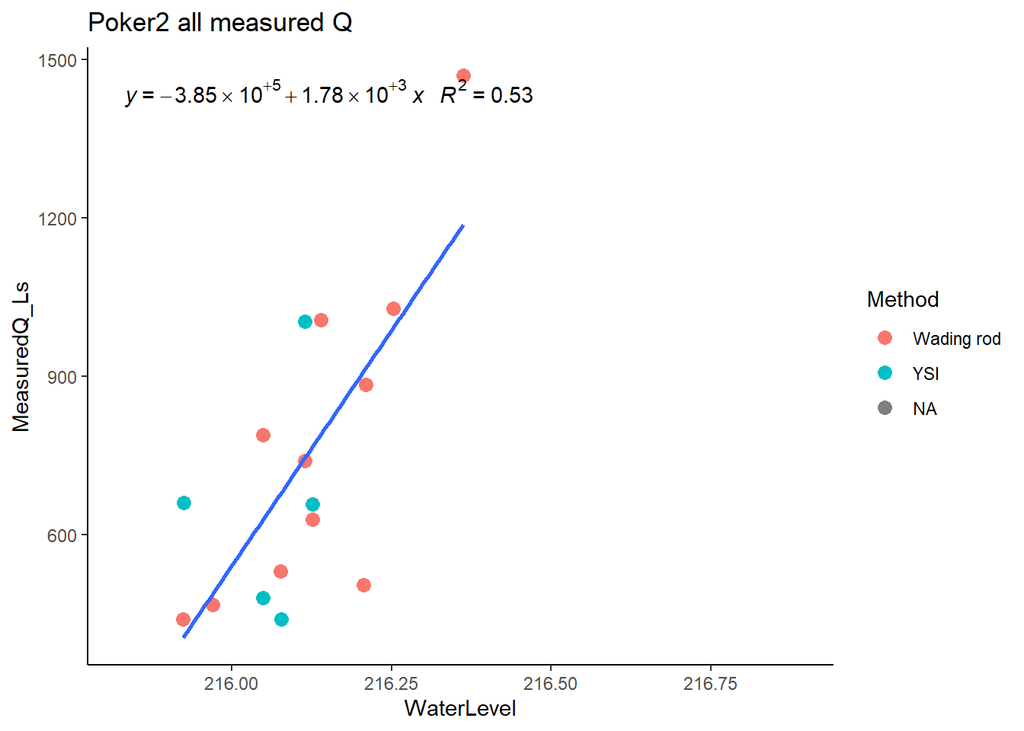

1. removed the top YSI point

## Final Q for POKE PT1

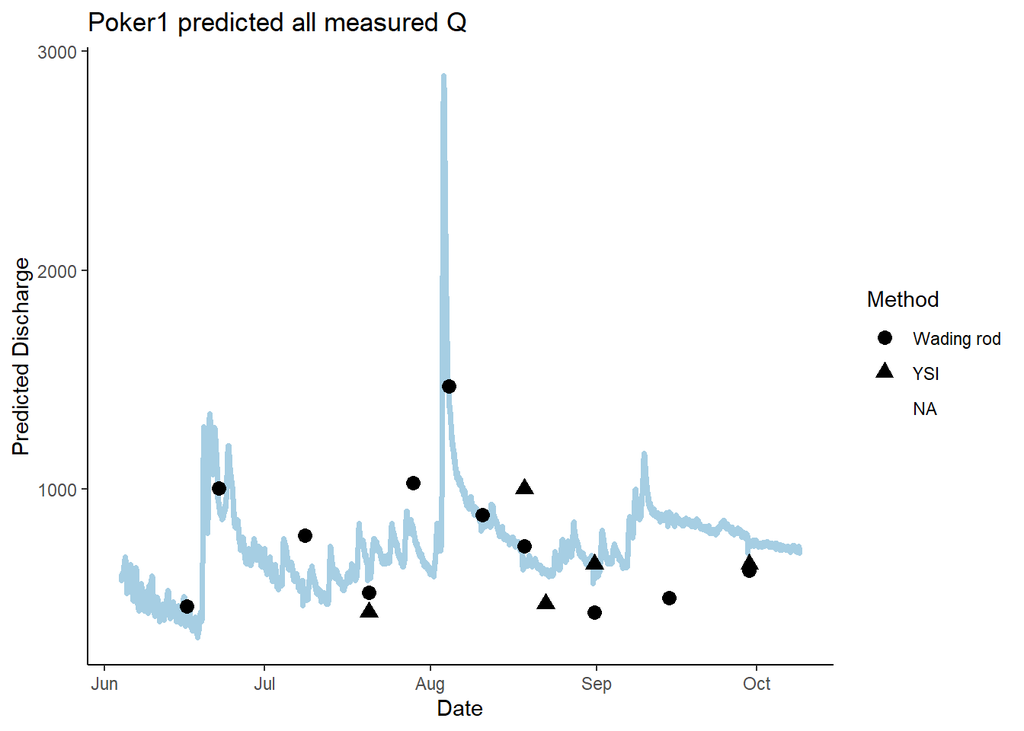

Seems like the predicted overshoots our discrete measurements

## Final Q for POKE PT2

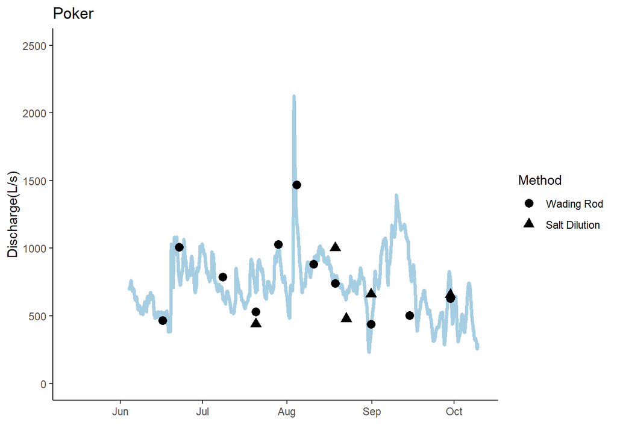

A lot noisier then PT1.

## Final Q POKE average

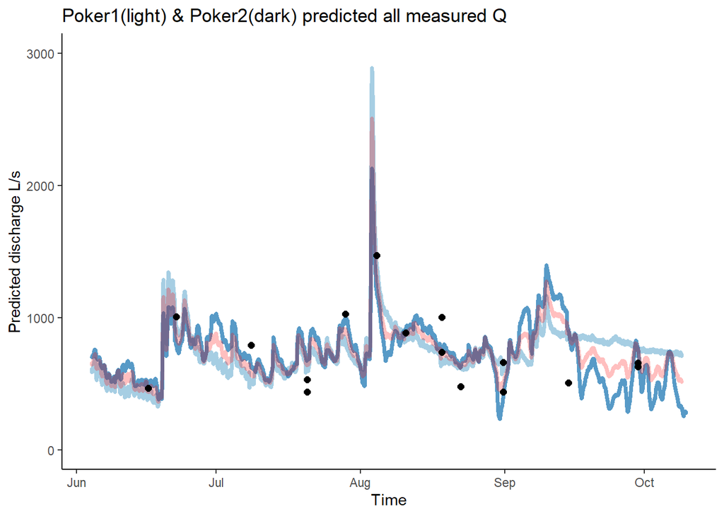

I think we should go with PT1

## Export PT data to csv in DoD_Discharge->Predicted_Discharge->2020

# Vault

## Raw Vault PT1

There is only one Vault PT

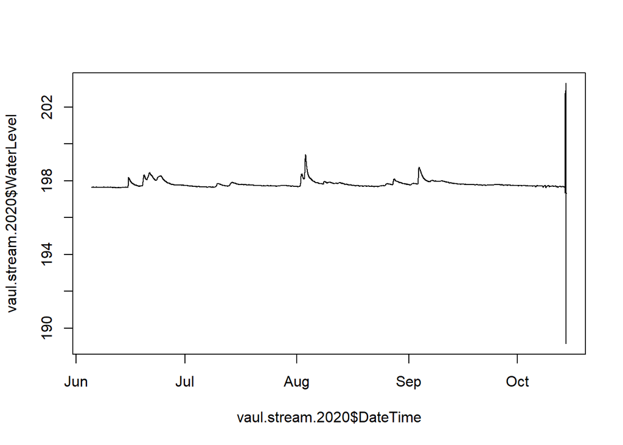

Hard to see what else we need to clean besides the end of the year out of water points….let the cleaning commence!

## Vault PT1 2.0

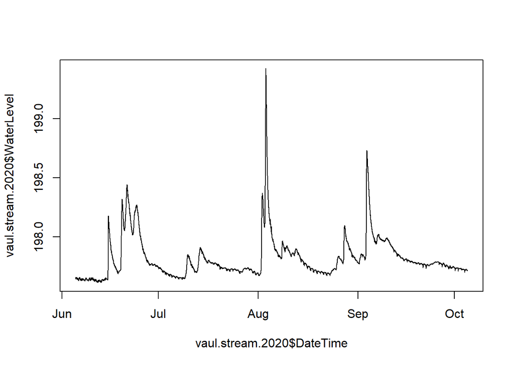

1. removed data after 10/5/20 due to out of water points

## Export PT data to csv in DoD_Discharge->PT_data->2020

## Raw rating curve for VAUL PT1

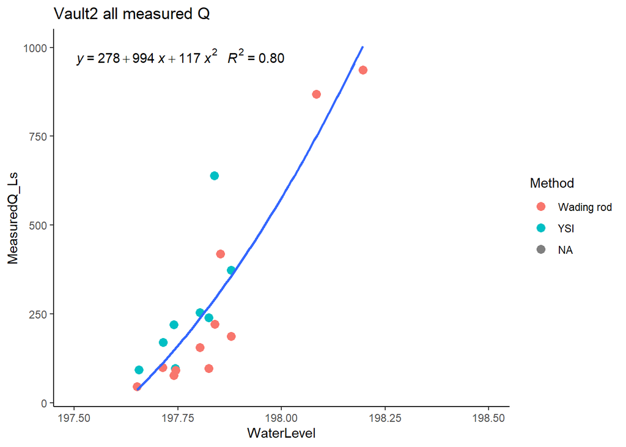

## Predicted Q for VAUL

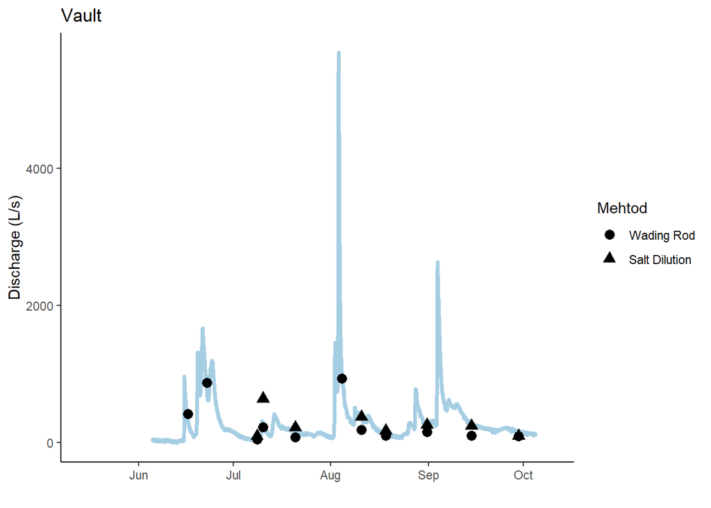

Not too shabby!

## Export PT data to csv in DoD_Discharge->Predicted_Discharge->2020

# Stuart

## Raw STRT PT1

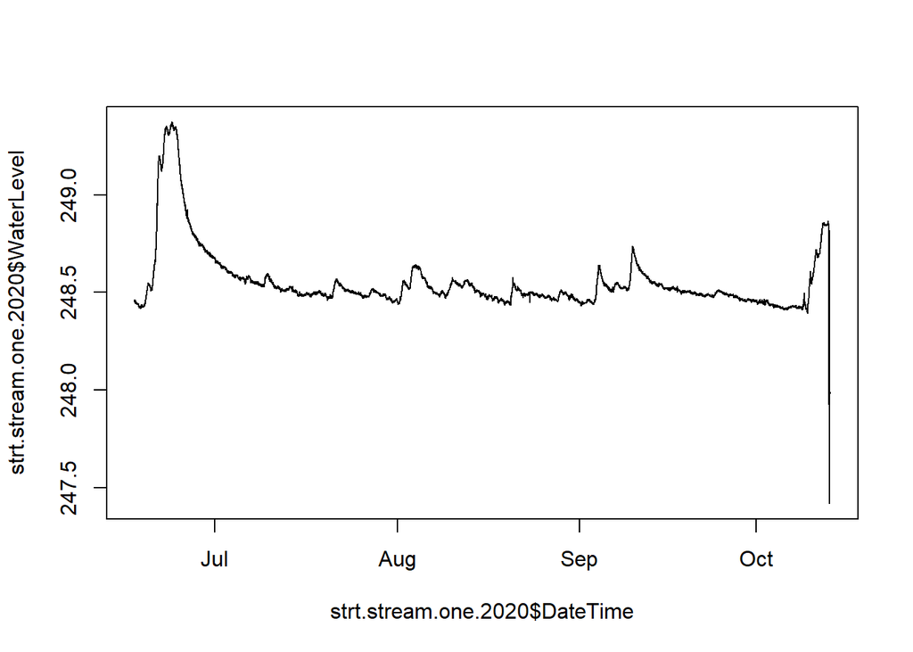

Needs end of season out of water points to be removed….let the cleaning commence!

STRT PT1 2.0

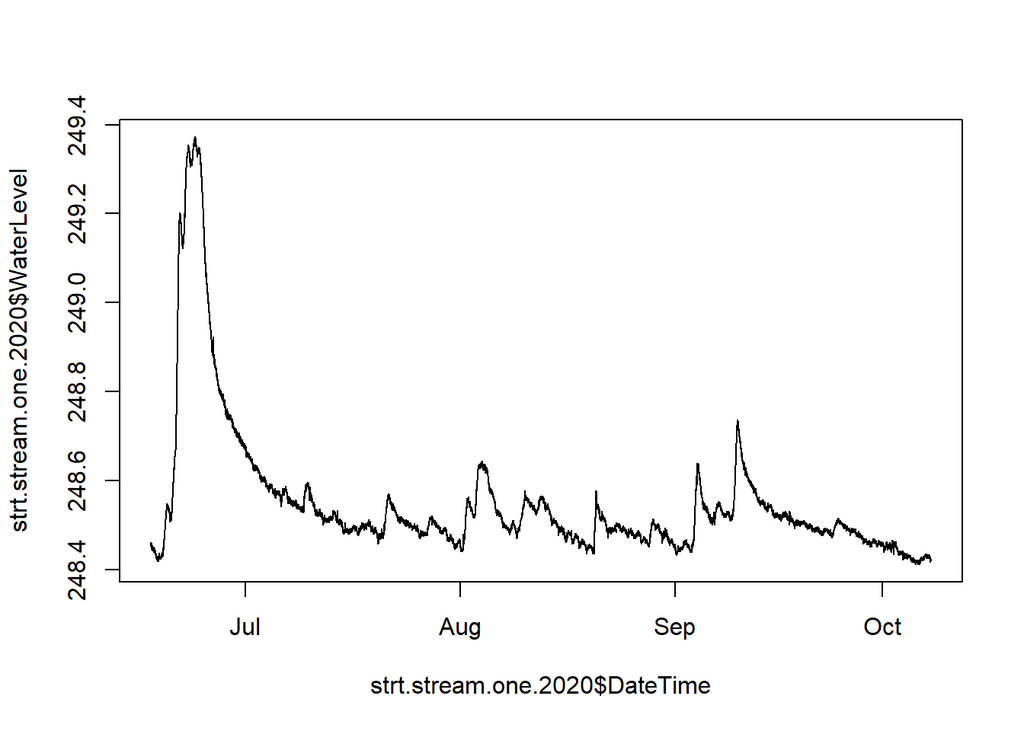

1. Removed data after 10/8/20 due to ice on the channel…PT was taken out on the 13th
2. removed vertical bar errant point in middle of August

## Raw STRT PT2

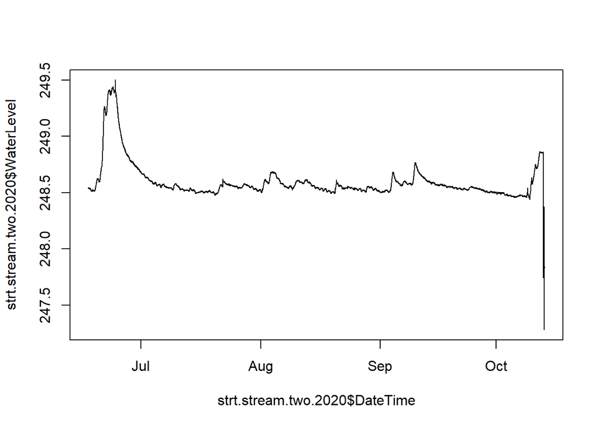

Same procedure as previous PT….let the cleaning commence!

STRT PT2 2.0

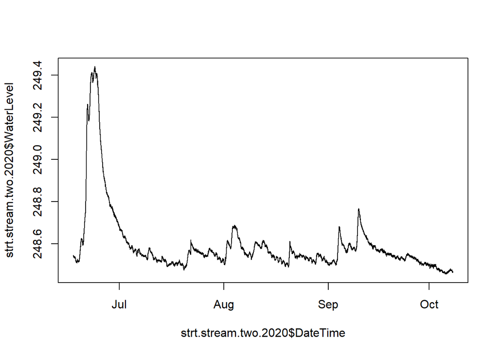

1. Removed vertical errant point at the top of first big storm
2. Removed data after 10/8 due to ice on the channel…PT was taken out on the 13th

## Export PT data to csv in DoD_Discharge->PT_data->2020

## Raw rating curve for STRT PT1

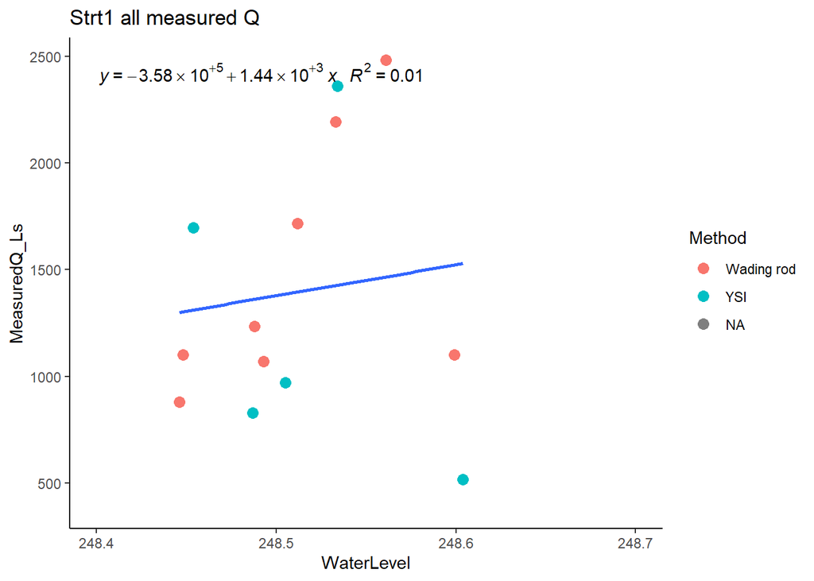

Does not look pretty

## Rating curve for STRT PT1 2.0

```
##
## Call:
## lm(formula = Strt1comb.2020$MeasuredQ_Ls ~ Strt1comb.2020$WaterLevel)
##
## Residuals:
##     Min      1Q  Median      3Q     Max
## -577.64 -238.40   80.56  221.85  406.42
##
## Coefficients:
##                           Estimate Std. Error t value Pr(>|t|)
## (Intercept)               -3717332     816593  -4.552  0.00187 **
## Strt1comb.2020$WaterLevel    14965       3286   4.554  0.00186 **
## ---
## Signif. codes:  0 '***' 0.001 '**' 0.01 '*' 0.05 '.' 0.1 ' ' 1
##
## Residual standard error: 361.6 on 8 degrees of freedom
##   (10807 observations deleted due to missingness)
## Multiple R-squared:  0.7216, Adjusted R-squared:  0.6868
## F-statistic: 20.74 on 1 and 8 DF,  p-value: 0.001864
```

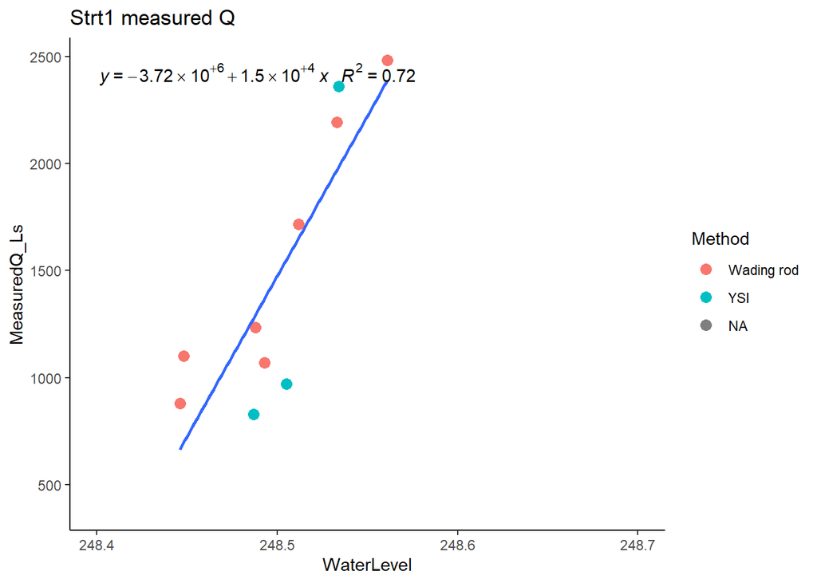

## Raw rating curve for STRT PT2

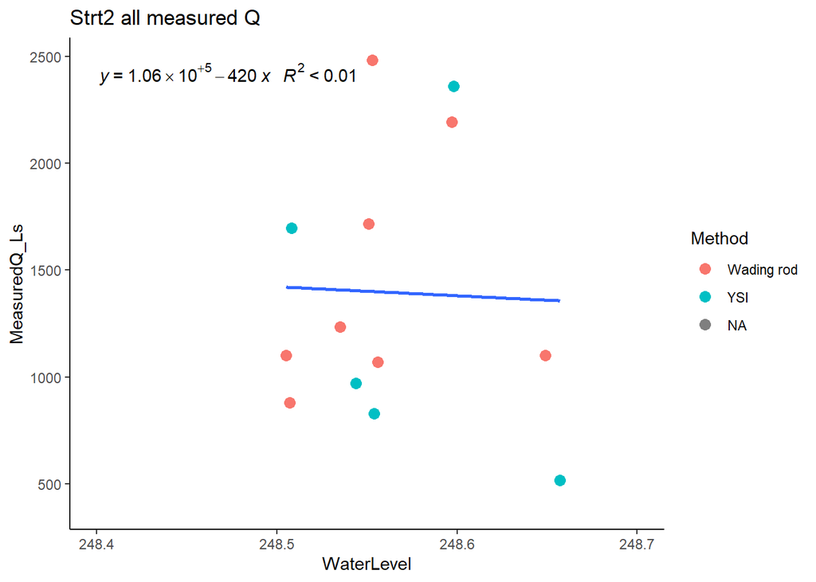

Negative slope is definitely bad

Rating curve for STRT PT2 2.0

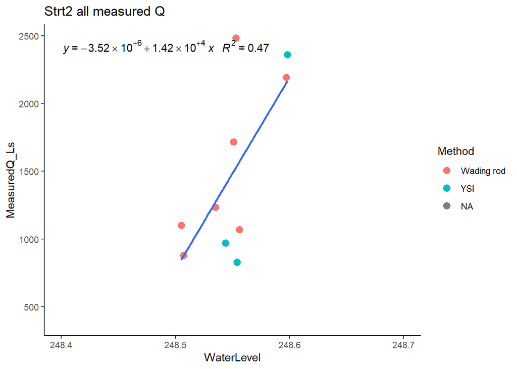

Yikes.

## Predicted Q for STRT PT1

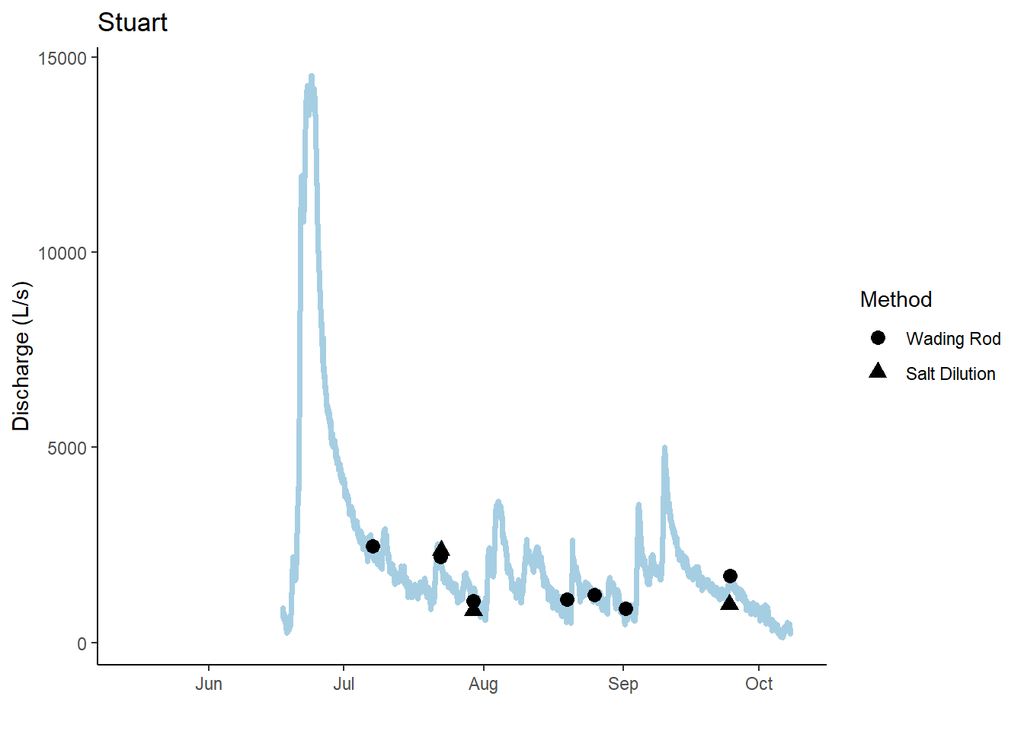

Not too shabby

## Predicted Q for STRT PT2

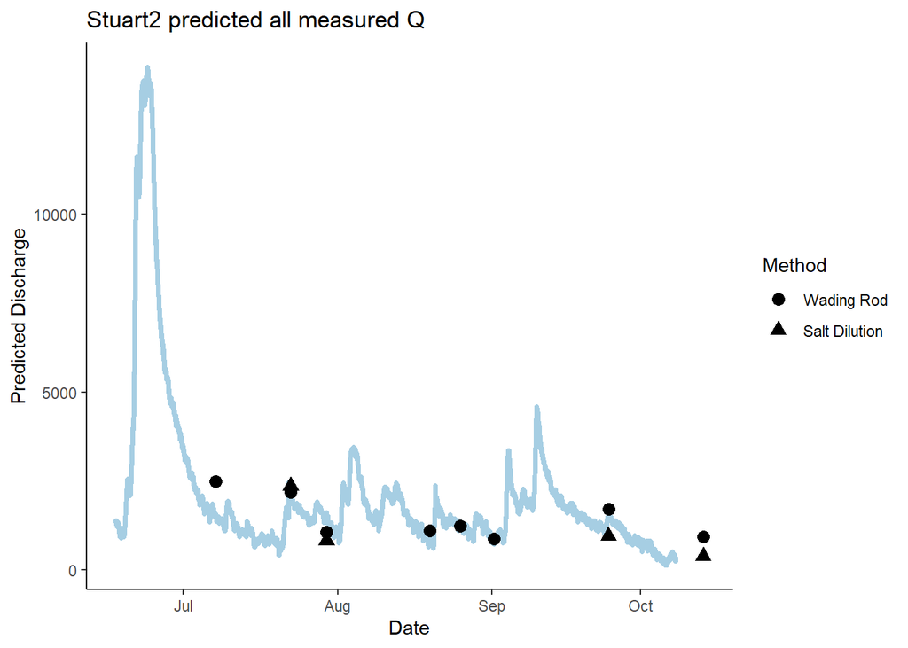

Not as good as PT1.

## Predicted Q for STRT

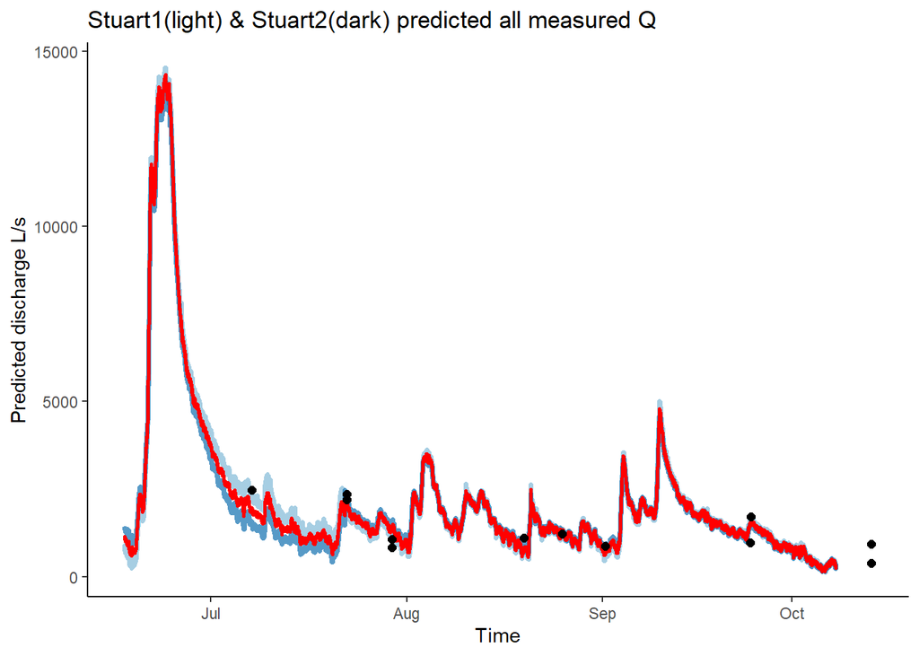

## Export PT data to csv in DoD_Discharge->Predicted_Discharge->2020

## Export PT data to csv in DoD_Discharge->Predicted_Discharge->2020